# Risk Factor Analysis

## Outcome Variable

**Outcome Variable:** dead6plus

## Predictor Variables

**Intervention Variable:** ever_underweight024

**Adjustment Set:**

- sex
- arm
- brthmon
- vagbrth
- hhwealth_quart
- W_mage
- W_mhtcm
- W_mwtkg
- W_mbmi
- W_meducyrs
- W_feducyrs
- W_nrooms
- W_parity
- impsan
- safeh20
- delta_vagbrth
- delta_hhwealth_quart
- delta_W_mage
- delta_W_mhtcm
- delta_W_mwtkg
- delta_W_mbmi
- delta_W_meducyrs
- delta_W_feducyrs
- delta_W_nrooms
- delta_W_parity
- delta_impsan
- delta_safeh20

## Stratifying Variables

The analysis was stratified on these variable(s):

- studyid
- country

## Data Summary

| studyid | country | ever_underweight024 | dead6plus | n_cell | n | outcome_variable |
| --- | --- | --- | --- | --- | --- | --- |
| ki0047075b-MAL-ED | BANGLADESH | 0 | 0 | 109 | 240 | dead6plus |
| ki0047075b-MAL-ED | BANGLADESH | 0 | 1 | 0 | 240 | dead6plus |
| ki0047075b-MAL-ED | BANGLADESH | 1 | 0 | 131 | 240 | dead6plus |
| ki0047075b-MAL-ED | BANGLADESH | 1 | 1 | 0 | 240 | dead6plus |
| ki0047075b-MAL-ED | INDIA | 0 | 0 | 87 | 235 | dead6plus |
| ki0047075b-MAL-ED | INDIA | 0 | 1 | 0 | 235 | dead6plus |
| ki0047075b-MAL-ED | INDIA | 1 | 0 | 148 | 235 | dead6plus |
| ki0047075b-MAL-ED | INDIA | 1 | 1 | 0 | 235 | dead6plus |
| ki0047075b-MAL-ED | PERU | 0 | 0 | 204 | 273 | dead6plus |
| ki0047075b-MAL-ED | PERU | 0 | 1 | 1 | 273 | dead6plus |
| ki0047075b-MAL-ED | PERU | 1 | 0 | 68 | 273 | dead6plus |
| ki0047075b-MAL-ED | PERU | 1 | 1 | 0 | 273 | dead6plus |
| ki0047075b-MAL-ED | SOUTH AFRICA | 0 | 0 | 176 | 261 | dead6plus |
| ki0047075b-MAL-ED | SOUTH AFRICA | 0 | 1 | 0 | 261 | dead6plus |
| ki0047075b-MAL-ED | SOUTH AFRICA | 1 | 0 | 85 | 261 | dead6plus |
| ki0047075b-MAL-ED | SOUTH AFRICA | 1 | 1 | 0 | 261 | dead6plus |
| ki0047075b-MAL-ED | TANZANIA, UNITED REPUBLIC OF | 0 | 0 | 135 | 245 | dead6plus |
| ki0047075b-MAL-ED | TANZANIA, UNITED REPUBLIC OF | 0 | 1 | 0 | 245 | dead6plus |
| ki0047075b-MAL-ED | TANZANIA, UNITED REPUBLIC OF | 1 | 0 | 110 | 245 | dead6plus |
| ki0047075b-MAL-ED | TANZANIA, UNITED REPUBLIC OF | 1 | 1 | 0 | 245 | dead6plus |
| ki1000109-EE | PAKISTAN | 0 | 0 | 52 | 375 | dead6plus |
| ki1000109-EE | PAKISTAN | 0 | 1 | 0 | 375 | dead6plus |
| ki1000109-EE | PAKISTAN | 1 | 0 | 319 | 375 | dead6plus |
| ki1000109-EE | PAKISTAN | 1 | 1 | 4 | 375 | dead6plus |
| ki1000304-VITAMIN-A | INDIA | 0 | 0 | 1242 | 3615 | dead6plus |
| ki1000304-VITAMIN-A | INDIA | 0 | 1 | 4 | 3615 | dead6plus |
| ki1000304-VITAMIN-A | INDIA | 1 | 0 | 2341 | 3615 | dead6plus |
| ki1000304-VITAMIN-A | INDIA | 1 | 1 | 28 | 3615 | dead6plus |
| ki1000304b-SAS-CompFeed | INDIA | 0 | 0 | 539 | 1389 | dead6plus |
| ki1000304b-SAS-CompFeed | INDIA | 0 | 1 | 0 | 1389 | dead6plus |
| ki1000304b-SAS-CompFeed | INDIA | 1 | 0 | 838 | 1389 | dead6plus |
| ki1000304b-SAS-CompFeed | INDIA | 1 | 1 | 12 | 1389 | dead6plus |
| ki1000304b-SAS-FoodSuppl | INDIA | 0 | 0 | 67 | 402 | dead6plus |
| ki1000304b-SAS-FoodSuppl | INDIA | 0 | 1 | 1 | 402 | dead6plus |
| ki1000304b-SAS-FoodSuppl | INDIA | 1 | 0 | 331 | 402 | dead6plus |
| ki1000304b-SAS-FoodSuppl | INDIA | 1 | 1 | 3 | 402 | dead6plus |
| ki1017093b-PROVIDE | BANGLADESH | 0 | 0 | 294 | 617 | dead6plus |
| ki1017093b-PROVIDE | BANGLADESH | 0 | 1 | 1 | 617 | dead6plus |
| ki1017093b-PROVIDE | BANGLADESH | 1 | 0 | 320 | 617 | dead6plus |
| ki1017093b-PROVIDE | BANGLADESH | 1 | 1 | 2 | 617 | dead6plus |
| ki1066203-TanzaniaChild2 | TANZANIA, UNITED REPUBLIC OF | 0 | 0 | 1589 | 2096 | dead6plus |
| ki1066203-TanzaniaChild2 | TANZANIA, UNITED REPUBLIC OF | 0 | 1 | 0 | 2096 | dead6plus |
| ki1066203-TanzaniaChild2 | TANZANIA, UNITED REPUBLIC OF | 1 | 0 | 507 | 2096 | dead6plus |
| ki1066203-TanzaniaChild2 | TANZANIA, UNITED REPUBLIC OF | 1 | 1 | 0 | 2096 | dead6plus |
| ki1101329-Keneba | GAMBIA | 0 | 0 | 1472 | 2761 | dead6plus |
| ki1101329-Keneba | GAMBIA | 0 | 1 | 34 | 2761 | dead6plus |
| ki1101329-Keneba | GAMBIA | 1 | 0 | 1210 | 2761 | dead6plus |
| ki1101329-Keneba | GAMBIA | 1 | 1 | 45 | 2761 | dead6plus |
| ki1112895-Burkina Faso Zn | BURKINA FASO | 0 | 0 | 4723 | 7163 | dead6plus |
| ki1112895-Burkina Faso Zn | BURKINA FASO | 0 | 1 | 22 | 7163 | dead6plus |
| ki1112895-Burkina Faso Zn | BURKINA FASO | 1 | 0 | 2392 | 7163 | dead6plus |
| ki1112895-Burkina Faso Zn | BURKINA FASO | 1 | 1 | 26 | 7163 | dead6plus |
| ki1113344-GMS-Nepal | NEPAL | 0 | 0 | 151 | 592 | dead6plus |
| ki1113344-GMS-Nepal | NEPAL | 0 | 1 | 1 | 592 | dead6plus |
| ki1113344-GMS-Nepal | NEPAL | 1 | 0 | 439 | 592 | dead6plus |
| ki1113344-GMS-Nepal | NEPAL | 1 | 1 | 1 | 592 | dead6plus |
| ki1126311-ZVITAMBO | ZIMBABWE | 0 | 0 | 8562 | 11708 | dead6plus |
| ki1126311-ZVITAMBO | ZIMBABWE | 0 | 1 | 139 | 11708 | dead6plus |
| ki1126311-ZVITAMBO | ZIMBABWE | 1 | 0 | 2730 | 11708 | dead6plus |
| ki1126311-ZVITAMBO | ZIMBABWE | 1 | 1 | 277 | 11708 | dead6plus |
| ki1148112-iLiNS-DOSE | MALAWI | 0 | 0 | 1115 | 1874 | dead6plus |
| ki1148112-iLiNS-DOSE | MALAWI | 0 | 1 | 63 | 1874 | dead6plus |
| ki1148112-iLiNS-DOSE | MALAWI | 1 | 0 | 632 | 1874 | dead6plus |
| ki1148112-iLiNS-DOSE | MALAWI | 1 | 1 | 64 | 1874 | dead6plus |
| ki1148112-iLiNS-DYAD-M | MALAWI | 0 | 0 | 751 | 1161 | dead6plus |
| ki1148112-iLiNS-DYAD-M | MALAWI | 0 | 1 | 14 | 1161 | dead6plus |
| ki1148112-iLiNS-DYAD-M | MALAWI | 1 | 0 | 382 | 1161 | dead6plus |
| ki1148112-iLiNS-DYAD-M | MALAWI | 1 | 1 | 14 | 1161 | dead6plus |
| kiGH5241-JiVitA-3 | BANGLADESH | 0 | 0 | 9914 | 21046 | dead6plus |
| kiGH5241-JiVitA-3 | BANGLADESH | 0 | 1 | 109 | 21046 | dead6plus |
| kiGH5241-JiVitA-3 | BANGLADESH | 1 | 0 | 10820 | 21046 | dead6plus |
| kiGH5241-JiVitA-3 | BANGLADESH | 1 | 1 | 203 | 21046 | dead6plus |
| kiGH5241-JiVitA-4 | BANGLADESH | 0 | 0 | 2562 | 5433 | dead6plus |
| kiGH5241-JiVitA-4 | BANGLADESH | 0 | 1 | 13 | 5433 | dead6plus |
| kiGH5241-JiVitA-4 | BANGLADESH | 1 | 0 | 2821 | 5433 | dead6plus |
| kiGH5241-JiVitA-4 | BANGLADESH | 1 | 1 | 37 | 5433 | dead6plus |

The following strata were considered:

- studyid: ki0047075b-MAL-ED, country: BANGLADESH
- studyid: ki0047075b-MAL-ED, country: INDIA
- studyid: ki0047075b-MAL-ED, country: PERU
- studyid: ki0047075b-MAL-ED, country: SOUTH AFRICA
- studyid: ki0047075b-MAL-ED, country: TANZANIA, UNITED REPUBLIC OF
- studyid: ki1000109-EE, country: PAKISTAN
- studyid: ki1000304-VITAMIN-A, country: INDIA
- studyid: ki1000304b-SAS-CompFeed, country: INDIA
- studyid: ki1000304b-SAS-FoodSuppl, country: INDIA
- studyid: ki1017093b-PROVIDE, country: BANGLADESH
- studyid: ki1066203-TanzaniaChild2, country: TANZANIA, UNITED REPUBLIC OF
- studyid: ki1101329-Keneba, country: GAMBIA
- studyid: ki1112895-Burkina Faso Zn, country: BURKINA FASO
- studyid: ki1113344-GMS-Nepal, country: NEPAL
- studyid: ki1126311-ZVITAMBO, country: ZIMBABWE
- studyid: ki1148112-iLiNS-DOSE, country: MALAWI
- studyid: ki1148112-iLiNS-DYAD-M, country: MALAWI
- studyid: kiGH5241-JiVitA-3, country: BANGLADESH
- studyid: kiGH5241-JiVitA-4, country: BANGLADESH

### Dropped Strata

Some strata were dropped due to rare outcomes:

- studyid: ki0047075b-MAL-ED, country: BANGLADESH
- studyid: ki0047075b-MAL-ED, country: INDIA
- studyid: ki0047075b-MAL-ED, country: PERU
- studyid: ki0047075b-MAL-ED, country: SOUTH AFRICA
- studyid: ki0047075b-MAL-ED, country: TANZANIA, UNITED REPUBLIC OF
- studyid: ki1000109-EE, country: PAKISTAN
- studyid: ki1000304-VITAMIN-A, country: INDIA
- studyid: ki1000304b-SAS-CompFeed, country: INDIA
- studyid: ki1000304b-SAS-FoodSuppl, country: INDIA
- studyid: ki1017093b-PROVIDE, country: BANGLADESH
- studyid: ki1066203-TanzaniaChild2, country: TANZANIA, UNITED REPUBLIC OF
- studyid: ki1113344-GMS-Nepal, country: NEPAL

## Methods Detail

We’re interested in the causal parameters $E[Y_a]$ for all values of $a \in \mathcal{A}$. These parameters represent the mean outcome if, possibly contrary to fact, we intervened to set all units to have $A=a$. Under the randomization and positivity assumptions, these are identified by the statistical parameters $\psi_a=E_W[E_{Y|A,W}(Y|A=a,W)]$. In addition, we’re interested in the mean of $Y$, $E[Y]$ under no intervention (the observed mean). We will estimate these parameters by using SuperLearner to fit the relevant likelihood factors – $E_{Y|A,W}(Y|A=a,W)$ and $p(A=a|W)$, and then updating our likelihood fit using a joint TMLE.

For unadjusted analyses ($W=\{\}$), initial likelihoods were estimated using Lrnr_glm to estimate the simple $E(Y|A)$ and Lrnr_mean to estimate $p(A)$. For adjusted analyses, a small library containing Lrnr_glmnet, Lrnr_xgboost, and Lrnr_mean was used.

Having estimated these parameters, we will then use the delta method to estimate relative risks and attributable risks relative to a prespecified baseline level of $A$.

# Results Detail

## Results Plots

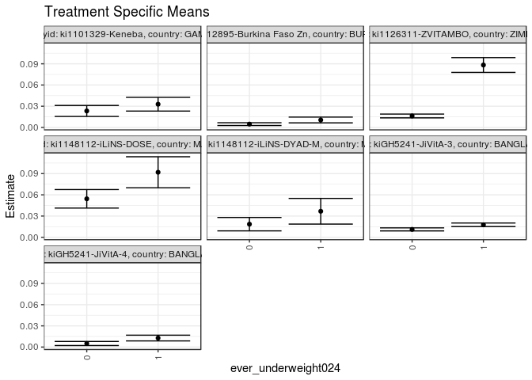

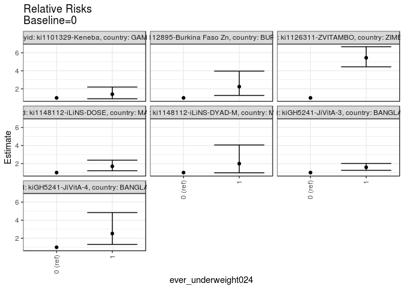

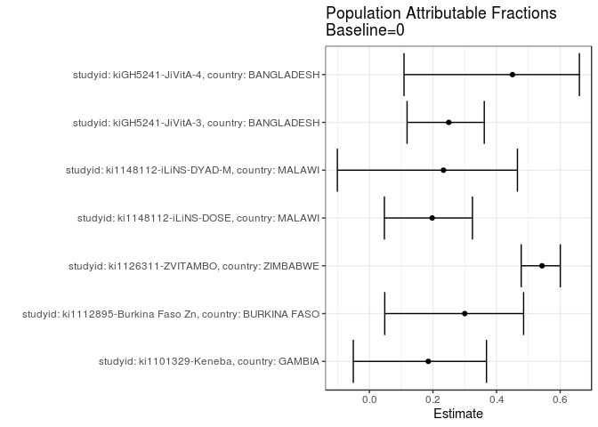

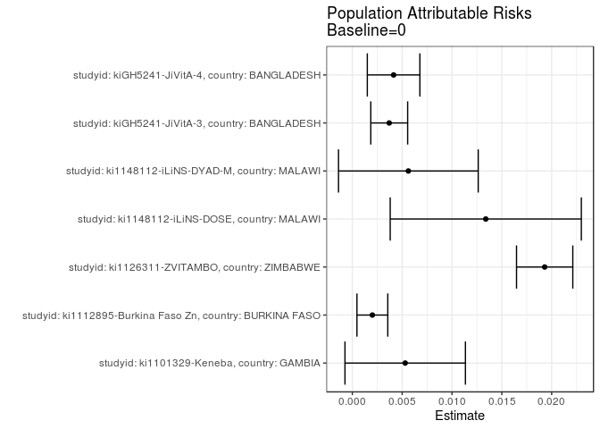

## Results Table

### Parameter: TSM

| studyid | country | intervention_level | baseline_level | estimate | ci_lower | ci_upper |
| --- | --- | --- | --- | --- | --- | --- |
| ki1101329-Keneba | GAMBIA | 0 | NA | 0.0233085 | 0.0155282 | 0.0310889 |
| ki1101329-Keneba | GAMBIA | 1 | NA | 0.0328395 | 0.0231515 | 0.0425276 |
| ki1112895-Burkina Faso Zn | BURKINA FASO | 0 | NA | 0.0046908 | 0.0027329 | 0.0066487 |
| ki1112895-Burkina Faso Zn | BURKINA FASO | 1 | NA | 0.0105273 | 0.0064495 | 0.0146051 |
| ki1126311-ZVITAMBO | ZIMBABWE | 0 | NA | 0.0162347 | 0.0135582 | 0.0189111 |
| ki1126311-ZVITAMBO | ZIMBABWE | 1 | NA | 0.0882908 | 0.0778168 | 0.0987648 |
| ki1148112-iLiNS-DOSE | MALAWI | 0 | NA | 0.0543816 | 0.0412777 | 0.0674855 |
| ki1148112-iLiNS-DOSE | MALAWI | 1 | NA | 0.0919373 | 0.0700125 | 0.1138621 |
| ki1148112-iLiNS-DYAD-M | MALAWI | 0 | NA | 0.0184944 | 0.0090258 | 0.0279630 |
| ki1148112-iLiNS-DYAD-M | MALAWI | 1 | NA | 0.0367764 | 0.0186152 | 0.0549377 |
| kiGH5241-JiVitA-3 | BANGLADESH | 0 | NA | 0.0111224 | 0.0089803 | 0.0132646 |
| kiGH5241-JiVitA-3 | BANGLADESH | 1 | NA | 0.0176087 | 0.0150973 | 0.0201202 |
| kiGH5241-JiVitA-4 | BANGLADESH | 0 | NA | 0.0050620 | 0.0021579 | 0.0079662 |
| kiGH5241-JiVitA-4 | BANGLADESH | 1 | NA | 0.0127604 | 0.0086919 | 0.0168290 |

### Parameter: E(Y)

| studyid | country | intervention_level | baseline_level | estimate | ci_lower | ci_upper |
| --- | --- | --- | --- | --- | --- | --- |
| ki1101329-Keneba | GAMBIA | NA | NA | 0.0286128 | 0.0223931 | 0.0348325 |
| ki1112895-Burkina Faso Zn | BURKINA FASO | NA | NA | 0.0067011 | 0.0048116 | 0.0085906 |
| ki1126311-ZVITAMBO | ZIMBABWE | NA | NA | 0.0355313 | 0.0321779 | 0.0388846 |
| ki1148112-iLiNS-DOSE | MALAWI | NA | NA | 0.0677695 | 0.0563864 | 0.0791525 |
| ki1148112-iLiNS-DYAD-M | MALAWI | NA | NA | 0.0241171 | 0.0152888 | 0.0329455 |
| kiGH5241-JiVitA-3 | BANGLADESH | NA | NA | 0.0148247 | 0.0131816 | 0.0164677 |
| kiGH5241-JiVitA-4 | BANGLADESH | NA | NA | 0.0092030 | 0.0066160 | 0.0117900 |

### Parameter: RR

| studyid | country | intervention_level | baseline_level | estimate | ci_lower | ci_upper |
| --- | --- | --- | --- | --- | --- | --- |
| ki1101329-Keneba | GAMBIA | 0 | 0 | 1.000000 | 1.0000000 | 1.000000 |
| ki1101329-Keneba | GAMBIA | 1 | 0 | 1.408906 | 0.9022175 | 2.200152 |
| ki1112895-Burkina Faso Zn | BURKINA FASO | 0 | 0 | 1.000000 | 1.0000000 | 1.000000 |
| ki1112895-Burkina Faso Zn | BURKINA FASO | 1 | 0 | 2.244233 | 1.2699938 | 3.965832 |
| ki1126311-ZVITAMBO | ZIMBABWE | 0 | 0 | 1.000000 | 1.0000000 | 1.000000 |
| ki1126311-ZVITAMBO | ZIMBABWE | 1 | 0 | 5.438417 | 4.4393778 | 6.662281 |
| ki1148112-iLiNS-DOSE | MALAWI | 0 | 0 | 1.000000 | 1.0000000 | 1.000000 |
| ki1148112-iLiNS-DOSE | MALAWI | 1 | 0 | 1.690596 | 1.2042783 | 2.373302 |
| ki1148112-iLiNS-DYAD-M | MALAWI | 0 | 0 | 1.000000 | 1.0000000 | 1.000000 |
| ki1148112-iLiNS-DYAD-M | MALAWI | 1 | 0 | 1.988521 | 0.9748919 | 4.056055 |
| kiGH5241-JiVitA-3 | BANGLADESH | 0 | 0 | 1.000000 | 1.0000000 | 1.000000 |
| kiGH5241-JiVitA-3 | BANGLADESH | 1 | 0 | 1.583177 | 1.2474111 | 2.009320 |
| kiGH5241-JiVitA-4 | BANGLADESH | 0 | 0 | 1.000000 | 1.0000000 | 1.000000 |
| kiGH5241-JiVitA-4 | BANGLADESH | 1 | 0 | 2.520822 | 1.3134149 | 4.838186 |

### Parameter: PAR

| studyid | country | intervention_level | baseline_level | estimate | ci_lower | ci_upper |
| --- | --- | --- | --- | --- | --- | --- |
| ki1101329-Keneba | GAMBIA | 0 | NA | 0.0053043 | -0.0007383 | 0.0113469 |
| ki1112895-Burkina Faso Zn | BURKINA FASO | 0 | NA | 0.0020103 | 0.0004638 | 0.0035567 |
| ki1126311-ZVITAMBO | ZIMBABWE | 0 | NA | 0.0192966 | 0.0164734 | 0.0221199 |
| ki1148112-iLiNS-DOSE | MALAWI | 0 | NA | 0.0133879 | 0.0038003 | 0.0229755 |
| ki1148112-iLiNS-DYAD-M | MALAWI | 0 | NA | 0.0056228 | -0.0013858 | 0.0126313 |
| kiGH5241-JiVitA-3 | BANGLADESH | 0 | NA | 0.0037023 | 0.0018519 | 0.0055526 |
| kiGH5241-JiVitA-4 | BANGLADESH | 0 | NA | 0.0041410 | 0.0015039 | 0.0067781 |

### Parameter: PAF

| studyid | country | intervention_level | baseline_level | estimate | ci_lower | ci_upper |
| --- | --- | --- | --- | --- | --- | --- |
| ki1101329-Keneba | GAMBIA | 0 | NA | 0.1853811 | -0.0504631 | 0.3682748 |
| ki1112895-Burkina Faso Zn | BURKINA FASO | 0 | NA | 0.2999908 | 0.0484172 | 0.4850549 |
| ki1126311-ZVITAMBO | ZIMBABWE | 0 | NA | 0.5430881 | 0.4775015 | 0.6004420 |
| ki1148112-iLiNS-DOSE | MALAWI | 0 | NA | 0.1975506 | 0.0472732 | 0.3241241 |
| ki1148112-iLiNS-DYAD-M | MALAWI | 0 | NA | 0.2331441 | -0.1005237 | 0.4656471 |
| kiGH5241-JiVitA-3 | BANGLADESH | 0 | NA | 0.2497363 | 0.1186256 | 0.3613434 |
| kiGH5241-JiVitA-4 | BANGLADESH | 0 | NA | 0.4499611 | 0.1089366 | 0.6604700 |